# Lupus Patient Analysis — Century Health Take-Home

Data Analyst

2026-03-01

# Setup

```r
library(tidyverse)
library(lubridate)
library(readxl)
library(scales)
library(patchwork)
library(broom)
library(testthat)
library(knitr)

source("R/helpers.R")
```

```r
raw <- load_all_datasets("data")

# quick look at table sizes
for (nm in names(raw)) {
  cat(sprintf("%-12s %d x %d\n", paste0(nm, ":"), nrow(raw[[nm]]), ncol(raw[[nm]])))
}
```

```
## patients:    10000 x 27
## encounters:  104262 x 15
## symptoms:    1423 x 9
## medications: 22237 x 13
## conditions:  4149 x 6
```

# 1. Data Assessment

## 1.1 How the datasets connect

All five tables link through patient and encounter UUIDs:

```
                          ┌──────────────┐
                          │   PATIENTS   │
                          │ (PATIENT_ID) │
                          └──────┬───────┘
                                 │  1
              ┌──────────────────┼──────────────────┐
              │                  │                  │
              ▼ *                ▼ *                ▼ *
     ┌────────────────┐  ┌──────────────┐  ┌──────────────┐
     │  ENCOUNTERS    │  │  SYMPTOMS    │  │  MEDICATIONS │
     │  (Id)          │  │  (PATIENT)   │  │  (PATIENT,   │
     │  FK: PATIENT   │  │              │  │   ENCOUNTER) │
     └───────┬────────┘  └──────────────┘  └──────┬───────┘
             │ 1                                  │
             │            ┌──────────────┐        │
             └───────────►│  CONDITIONS  │◄───────┘
                     *    │  (PATIENT,   │    *
                          │   ENCOUNTER) │
                          └──────────────┘
```

| From | To | Join Key |
| --- | --- | --- |
| Patients → Encounters | `PATIENT_ID` = `PATIENT` |  |
| Patients → Symptoms | `PATIENT_ID` = `PATIENT` |  |
| Patients → Medications | `PATIENT_ID` = `PATIENT` |  |
| Patients → Conditions | `PATIENT_ID` = `PATIENT` |  |
| Encounters → Medications | `Id` = `ENCOUNTER` |  |
| Encounters → Conditions | `Id` = `ENCOUNTER` |  |

> The raw encounters file is Parquet. Since `arrow` isn’t always available in R, I included a pre-converted `encounters.csv` in the submission. See `R/helpers.R` for how to regenerate it.

## 1.2 Data quality issues

| # | Issue | Impact | Fix |
| --- | --- | --- | --- |
| 1 | Mixed-case UUIDs across files | Joins silently drop rows | Lowercase everything |
| 2 | Same drug in 3+ casing variants | Inflated med counts | Uppercase + trim |
| 3 | GENDER is all NA in symptoms | Can’t stratify by gender | Backfill from patients |
| 4 | Dates stored as strings | No time-based analysis | Parse to Date/POSIXct |
| 5 | Symptom scores packed in one string | Not usable for analysis | Regex into 4 columns |
| 6 | Symptoms has duplicate rows per patient (Lupus + Anemia) | Overstates N, mixes conditions | Filter to Lupus, deduplicate |
| 7 | Mix of CSV, Parquet, XLSX | Loading hassle | Handled in `load_all_datasets()` |

## 1.3 Two Lupus cohorts

There are two ways to slice “Lupus patients” in this data, and they end up being different sizes:

| Cohort | Definition | Used in |
| --- | --- | --- |
| **Diagnosed cohort** | Patients with at least 1 Lupus record in `conditions` | Sections 3.1–3.3 |
| **Symptom-observed subset** | Diagnosed patients who also have a Lupus row in `symptoms` | Sections 3.4, 4, 5 |

The symptom-observed subset is strictly contained within the diagnosed cohort. I’ll report the exact sizes after cleaning.

# 2. Cleaning

```r
# 1) lowercase IDs
datasets <- normalise_ids(raw)

# 2) standardise med names
datasets$medications <- standardise_medication_names(datasets$medications)
cat(sprintf("Unique medication descriptions after cleaning: %d\n",
            n_distinct(datasets$medications$DESCRIPTION)))
```

```
## Unique medication descriptions after cleaning: 5
```

```r
# 3) parse dates
datasets <- parse_dates(datasets)

# 4) parse symptom scores
datasets$symptoms <- parse_symptom_scores(datasets$symptoms)

# 5) keep only Lupus rows, one per patient
cat(sprintf("Symptoms before filter: %d rows, %d patients\n",
            nrow(datasets$symptoms), n_distinct(datasets$symptoms$PATIENT)))
```

```
## Symptoms before filter: 1423 rows, 948 patients
```

```r
datasets$symptoms <- filter_lupus_symptoms(datasets$symptoms)
cat(sprintf("Symptoms after filter:  %d rows, %d patients\n",
            nrow(datasets$symptoms), n_distinct(datasets$symptoms$PATIENT)))
```

```
## Symptoms after filter:  948 rows, 948 patients
```

```r
# 6) fill missing GENDER
datasets$symptoms <- fill_symptom_gender(datasets$symptoms, datasets$patients)
cat(sprintf("GENDER NAs remaining: %d\n", sum(is.na(datasets$symptoms$GENDER))))
```

```
## GENDER NAs remaining: 0
```

```r
# quick preview
datasets$symptoms %>%
  select(PATIENT, PATHOLOGY, Rash, Joint_Pain, Fatigue, Fever) %>%
  head(5) %>%
  kable(caption = "Parsed symptom scores (first 5)")
```

Parsed symptom scores (first 5)

| PATIENT | PATHOLOGY | Rash | Joint_Pain | Fatigue | Fever |
| --- | --- | --- | --- | --- | --- |
| 28d7b56c-6056-d0a2-2991-39d6e917216c | Lupus erythematosus | 34 | 39 | 9 | 12 |
| 6c434506-fb4b-3e3f-c19d-553dec3b6c17 | Lupus erythematosus | 19 | 44 | 48 | 15 |
| 44a8ca45-6c6e-38bb-fac0-ddbf7a7ee3a4 | Lupus erythematosus | 2 | 32 | 12 | 6 |
| 780ec78c-22a0-fcdb-17c6-ae9b2fcace9c | Lupus erythematosus | 30 | 30 | 41 | 19 |
| cf5956bb-34f2-841b-2505-57b99991c377 | Lupus erythematosus | 28 | 26 | 33 | 5 |

## Integrity tests

```r
run_integrity_tests(datasets)
```

Test passed Test passed Test passed Test passed Test passed Test passed Test passed Test passed Test passed Test passed Test passed Test passed

```r
cat("\n**All tests passed.**\n")
```

**All tests passed.**

```r
patients    <- datasets$patients
encounters  <- datasets$encounters
symptoms    <- datasets$symptoms
medications <- datasets$medications
conditions  <- datasets$conditions

# Diagnosed cohort: anyone with a Lupus condition record
lupus_patient_ids <- conditions %>%
  filter(str_to_upper(DESCRIPTION) == "LUPUS ERYTHEMATOSUS") %>%
  pull(PATIENT) %>%
  unique()

lupus_patients <- patients %>% filter(PATIENT_ID %in% lupus_patient_ids)

# Symptom-observed subset
symptom_patient_ids <- unique(symptoms$PATIENT)

n_total     <- n_distinct(patients$PATIENT_ID)
n_diagnosed <- n_distinct(lupus_patients$PATIENT_ID)
n_symptom   <- n_distinct(symptom_patient_ids)

tibble(
  Cohort     = c("All patients", "Diagnosed Lupus cohort", "Symptom-observed subset"),
  Definition = c("Everyone in patients.csv",
                 ">= 1 Lupus record in conditions",
                 "Diagnosed + has symptom data"),
  N          = c(comma(n_total), comma(n_diagnosed), comma(n_symptom))
) %>% kable(caption = "Cohort sizes")
```

Cohort sizes

| Cohort | Definition | N |
| --- | --- | --- |
| All patients | Everyone in patients.csv | 10,000 |
| Diagnosed Lupus cohort | >= 1 Lupus record in conditions | 2,784 |
| Symptom-observed subset | Diagnosed + has symptom data | 948 |

# 3. Descriptive Analysis

## 3.1 How many patients?

```r
cat(sprintf("Total patients:                %s\n", comma(n_total)))
```

```
## Total patients:                10,000
```

```r
cat(sprintf("Diagnosed with Lupus:          %s\n", comma(n_diagnosed)))
```

```
## Diagnosed with Lupus:          2,784
```

```r
cat(sprintf("With symptom observations:     %s\n", comma(n_symptom)))
```

```
## With symptom observations:     948
```

There are 10,000 patients in the dataset overall. 2,784 have a Lupus diagnosis in the conditions table, and 948 of those also have symptom data. The rest of Section 3 uses the diagnosed cohort unless noted.

## 3.2 Medications over time

I’m counting only Lupus-directed prescriptions here — ones where `REASONDESCRIPTION` is “Lupus erythematosus.” This excludes things like Vitamin B12 and ferrous sulfate that are really for comorbid anemia.

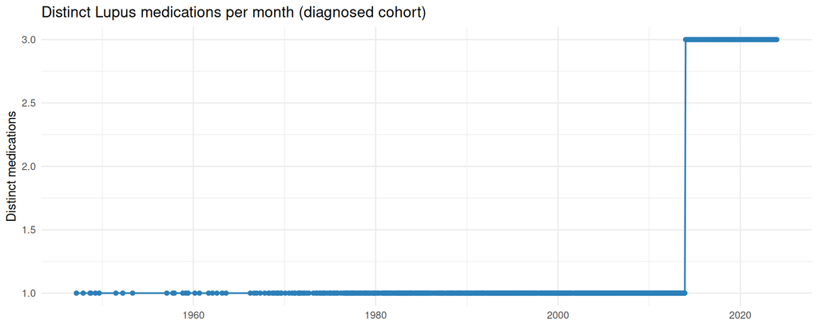

```r
lupus_meds <- medications %>%
  filter(PATIENT %in% lupus_patient_ids,
         str_to_upper(REASONDESCRIPTION) == "LUPUS ERYTHEMATOSUS")

meds_over_time <- lupus_meds %>%
  mutate(month = floor_date(START, "month")) %>%
  group_by(month) %>%
  summarise(n_meds = n_distinct(DESCRIPTION), .groups = "drop")

ggplot(meds_over_time, aes(month, n_meds)) +
  geom_line(colour = "#2c7fb8", linewidth = 0.7) +
  geom_point(colour = "#2c7fb8", size = 1.5) +
  scale_y_continuous(breaks = pretty_breaks()) +
  labs(title = "Distinct Lupus medications per month (diagnosed cohort)",
       x = NULL, y = "Distinct medications") +
  theme_minimal()
```

## 3.3 Race and gender breakdown

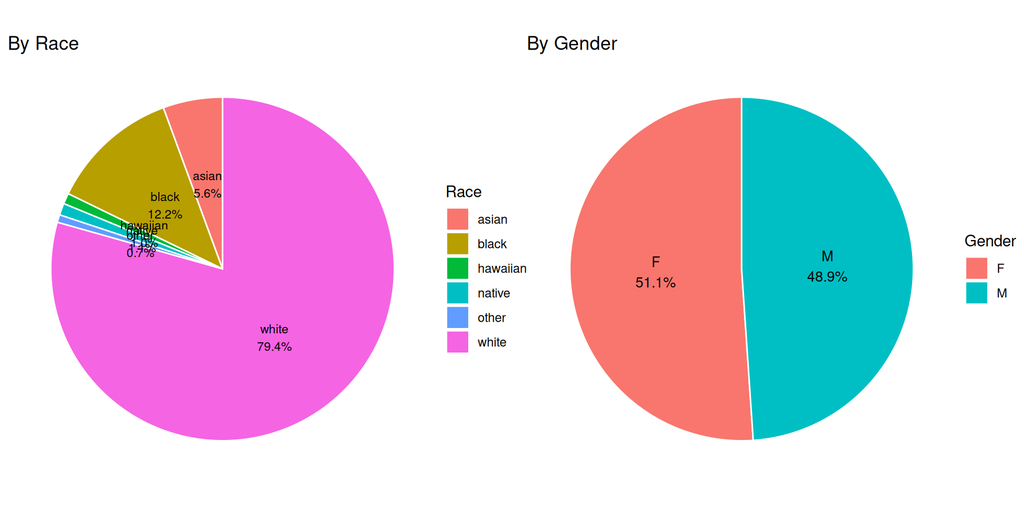

```r
race_data <- lupus_patients %>%
  count(RACE) %>%
  mutate(pct = n / sum(n),
         label = sprintf("%s\n%.1f%%", RACE, pct * 100))

p1 <- ggplot(race_data, aes(x = "", y = n, fill = RACE)) +
  geom_col(width = 1, colour = "white") +
  coord_polar("y") +
  geom_text(aes(label = label), position = position_stack(vjust = 0.5), size = 3) +
  labs(title = "By Race", fill = "Race") +
  theme_void()

gender_data <- lupus_patients %>%
  count(GENDER) %>%
  mutate(pct = n / sum(n),
         label = sprintf("%s\n%.1f%%", GENDER, pct * 100))

p2 <- ggplot(gender_data, aes(x = "", y = n, fill = GENDER)) +
  geom_col(width = 1, colour = "white") +
  coord_polar("y") +
  geom_text(aes(label = label), position = position_stack(vjust = 0.5), size = 3.5) +
  labs(title = "By Gender", fill = "Gender") +
  theme_void()

p1 + p2
```

## 3.4 High-symptom patients

How many patients in the symptom-observed subset have all four symptom scores at 30 or above?

```r
all_high <- symptoms %>%
  filter(Rash >= 30, Joint_Pain >= 30, Fatigue >= 30, Fever >= 30)

cat(sprintf("Patients with all 4 scores >= 30: %d / %d (%.1f%%)\n",
            nrow(all_high), nrow(symptoms),
            nrow(all_high) / nrow(symptoms) * 100))
```

```
## Patients with all 4 scores >= 30: 0 / 948 (0.0%)
```

# 4. Cohort Analysis

This section uses the symptom-observed subset (948 patients) since we need symptom scores for outcomes.

The plan is straightforward:

- Classify each prescription into a therapy group
- Figure out each patient’s primary therapy (most prescriptions; alphabetical tiebreak)
- Add age groups and composite symptom scores
- Compare outcomes across therapy, ethnicity, and age group

```r
lupus_meds <- lupus_meds %>% mutate(THERAPY = classify_therapy(DESCRIPTION))

cat("Therapy counts across all Lupus prescriptions:\n")
```

```
## Therapy counts across all Lupus prescriptions:
```

```r
lupus_meds %>% count(THERAPY, sort = TRUE) %>% kable()
```

| THERAPY | n |
| --- | --- |
| Prednisone (Corticosteroid) | 10046 |
| Cyclosporine (Immunosuppressant) | 9094 |
| Naproxen (NSAID) | 2784 |

```r
# narrow to symptom-observed patients
sym_meds <- lupus_meds %>% filter(PATIENT %in% symptom_patient_ids)

# primary therapy: whoever got the most prescriptions wins, alphabetical if tied
patient_therapy <- sym_meds %>%
  count(PATIENT, THERAPY, name = "n_rx") %>%
  arrange(PATIENT, desc(n_rx), THERAPY) %>%
  group_by(PATIENT) %>%
  slice_head(n = 1) %>%
  ungroup() %>%
  select(PATIENT, THERAPY)

cat("Primary therapy distribution:\n")
```

```
## Primary therapy distribution:
```

```r
patient_therapy %>% count(THERAPY, sort = TRUE) %>% kable()
```

| THERAPY | n |
| --- | --- |
| Prednisone (Corticosteroid) | 666 |
| Naproxen (NSAID) | 282 |

```r
symptoms <- symptoms %>%
  add_composite_score() %>%
  mutate(AGE_GROUP = assign_age_group(AGE_BEGIN))

cohort <- symptoms %>% inner_join(patient_therapy, by = "PATIENT")

# only keep therapy groups with at least 10 patients
therapy_counts <- cohort %>% count(THERAPY, sort = TRUE)
keep <- therapy_counts %>% filter(n >= 10) %>% pull(THERAPY)
cohort_main <- cohort %>% filter(THERAPY %in% keep)

cat(sprintf("Analysis cohort: %d patients\n", nrow(cohort_main)))
```

```
## Analysis cohort: 948 patients
```

```r
cat("Included therapies:\n")
```

```
## Included therapies:
```

```r
cohort_main %>% count(THERAPY, sort = TRUE) %>% kable()
```

| THERAPY | n |
| --- | --- |
| Prednisone (Corticosteroid) | 666 |
| Naproxen (NSAID) | 282 |

## 4.1 Symptom severity by therapy and age

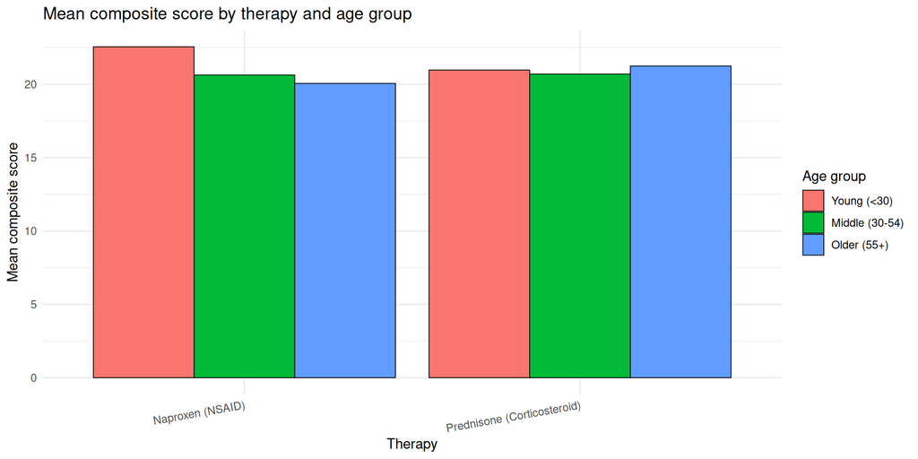

```r
summary_age <- cohort_main %>%
  group_by(THERAPY, AGE_GROUP) %>%
  summarise(mean_score = mean(COMPOSITE_SCORE), .groups = "drop")

ggplot(summary_age, aes(THERAPY, mean_score, fill = AGE_GROUP)) +
  geom_col(position = "dodge", colour = "black", linewidth = 0.3) +
  labs(title = "Mean composite score by therapy and age group",
       x = "Therapy", y = "Mean composite score", fill = "Age group") +
  theme_minimal() +
  theme(axis.text.x = element_text(angle = 10, hjust = 1))
```

## 4.2 Symptom severity by therapy and ethnicity

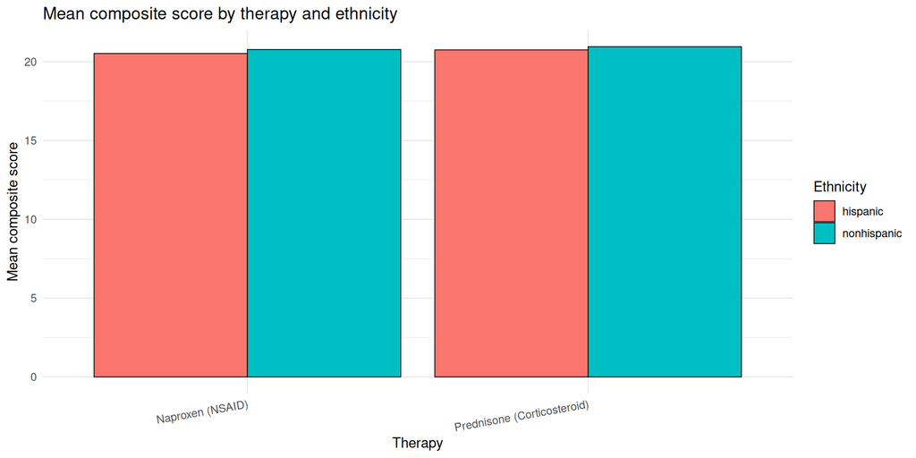

```r
summary_eth <- cohort_main %>%
  group_by(THERAPY, ETHNICITY) %>%
  summarise(mean_score = mean(COMPOSITE_SCORE), .groups = "drop")

ggplot(summary_eth, aes(THERAPY, mean_score, fill = ETHNICITY)) +
  geom_col(position = "dodge", colour = "black", linewidth = 0.3) +
  labs(title = "Mean composite score by therapy and ethnicity",
       x = "Therapy", y = "Mean composite score", fill = "Ethnicity") +
  theme_minimal() +
  theme(axis.text.x = element_text(angle = 10, hjust = 1))
```

## 4.3 Heatmap

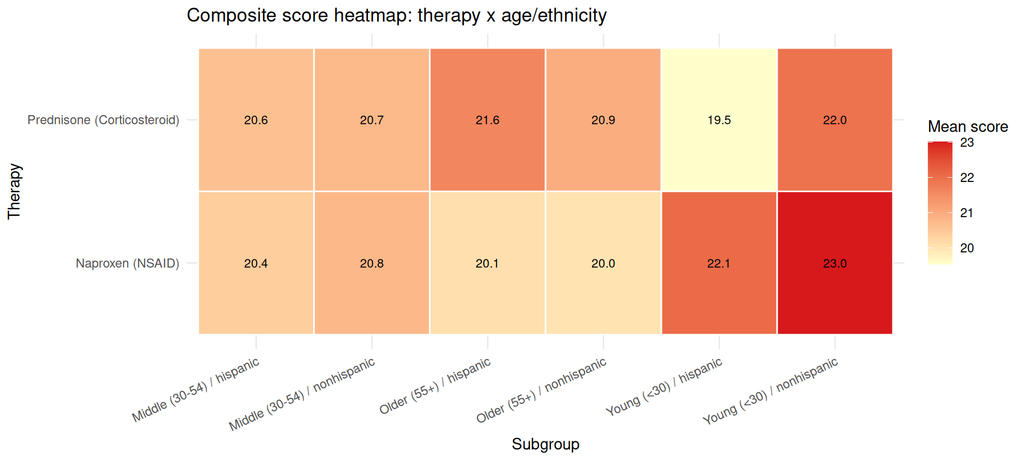

```r
cohort_main <- cohort_main %>%
  mutate(subgroup = paste(AGE_GROUP, "/", ETHNICITY))

heat <- cohort_main %>%
  group_by(THERAPY, subgroup) %>%
  summarise(mean_score = mean(COMPOSITE_SCORE), .groups = "drop")

ggplot(heat, aes(subgroup, THERAPY, fill = mean_score)) +
  geom_tile(colour = "white", linewidth = 0.5) +
  geom_text(aes(label = sprintf("%.1f", mean_score)), size = 3) +
  scale_fill_gradient(low = "#ffffcc", high = "#d7191c") +
  labs(title = "Composite score heatmap: therapy x age/ethnicity",
       x = "Subgroup", y = "Therapy", fill = "Mean score") +
  theme_minimal() +
  theme(axis.text.x = element_text(angle = 25, hjust = 1))
```

## 4.4 Symptom distributions

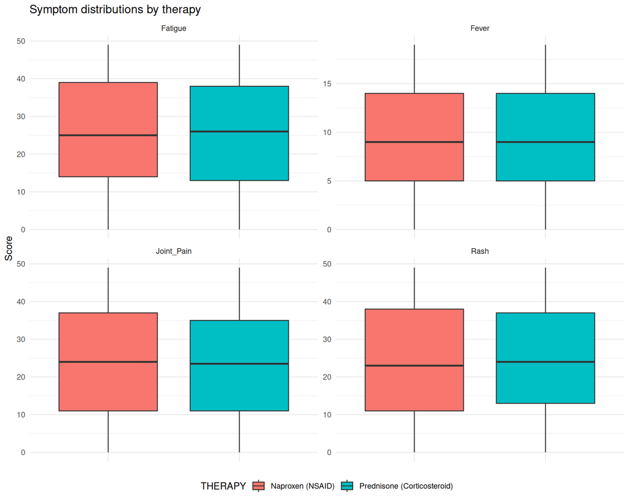

```r
long <- cohort_main %>%
  pivot_longer(c(Rash, Joint_Pain, Fatigue, Fever),
               names_to = "symptom", values_to = "score")

ggplot(long, aes(THERAPY, score, fill = THERAPY)) +
  geom_boxplot(outlier.size = 0.5) +
  facet_wrap(~symptom, scales = "free_y", ncol = 2) +
  labs(title = "Symptom distributions by therapy", x = NULL, y = "Score") +
  theme_minimal() +
  theme(axis.text.x = element_blank(), legend.position = "bottom")
```

## 4.5 What do we see?

```r
overall_means <- cohort_main %>%
  group_by(THERAPY) %>%
  summarise(n = n(),
            mean = round(mean(COMPOSITE_SCORE), 1),
            sd = round(sd(COMPOSITE_SCORE), 1),
            .groups = "drop")

kable(overall_means, col.names = c("Therapy", "N", "Mean", "SD"),
      caption = "Composite score summary by therapy")
```

Composite score summary by therapy

| Therapy | N | Mean | SD |
| --- | --- | --- | --- |
| Naproxen (NSAID) | 282 | 20.7 | 6.6 |
| Prednisone (Corticosteroid) | 666 | 20.9 | 6.3 |

```r
age_spread <- summary_age %>%
  group_by(THERAPY) %>%
  summarise(range = round(max(mean_score) - min(mean_score), 1), .groups = "drop")

eth_spread <- summary_eth %>%
  group_by(THERAPY) %>%
  summarise(range = round(max(mean_score) - min(mean_score), 1), .groups = "drop")

cat("\nWithin-therapy spread across age groups:\n")
```

```
##
## Within-therapy spread across age groups:
```

```r
print(age_spread)
```

```
## # A tibble: 2 x 2
##   THERAPY                     range
##   <chr>                       <dbl>
## 1 Naproxen (NSAID)              2.5
## 2 Prednisone (Corticosteroid)   0.5
```

```r
cat("\nWithin-therapy spread across ethnicities:\n")
```

```
##
## Within-therapy spread across ethnicities:
```

```r
print(eth_spread)
```

```
## # A tibble: 2 x 2
##   THERAPY                     range
##   <chr>                       <dbl>
## 1 Naproxen (NSAID)              0.3
## 2 Prednisone (Corticosteroid)   0.2
```

Looking at the results, there isn’t much differentiation between therapies — the means are close together and the standard deviations overlap. The within-therapy differences across age groups and ethnicities are also small (just a few points). The boxplots tell the same story: medians and IQRs overlap quite a bit. This is consistent with how Synthea generates data — symptom scores aren’t really driven by treatment assignment.

# 5. Statistical Modelling

The assignment asks for a model of whether symptoms decrease after medication. Unfortunately the symptom data is cross-sectional — each patient has one observation, not a before/after pair. There’s no way to measure change over time.

So instead I’m modelling a cross-sectional outcome: whether **Fatigue is below the cohort median**. Not ideal, but it’s the most honest thing I can do with the data we actually have.

Predictors: therapy type, age, gender, race, ethnicity, prescription count.

75/25 random split for train/test. Since we have one row per patient already, there’s no leakage concern.

```r
rx_counts <- sym_meds %>% count(PATIENT, name = "n_rx")

model_df <- cohort_main %>%
  left_join(rx_counts, by = "PATIENT") %>%
  filter(!is.na(GENDER), !is.na(RACE), !is.na(ETHNICITY)) %>%
  mutate(
    LOW_FATIGUE = as.integer(Fatigue < median(Fatigue)),
    THERAPY   = droplevels(factor(THERAPY)),
    GENDER    = droplevels(factor(GENDER)),
    RACE      = fct_lump_min(factor(RACE), min = 20, other_level = "other"),
    RACE      = if ("white" %in% levels(RACE)) relevel(RACE, ref = "white") else RACE,
    ETHNICITY = droplevels(factor(ETHNICITY))
  )

cat("Race levels after collapsing sparse categories:\n")
```

```
## Race levels after collapsing sparse categories:
```

```r
print(table(model_df$RACE))
```

```
##
## white asian black other
##   737    59   133    19
```

```r
# drop any single-level factors (can't use in regression)
single_lvl <- names(model_df)[sapply(model_df, function(x) is.factor(x) && nlevels(x) < 2)]
if (length(single_lvl) > 0) {
  cat("Dropping single-level factors:", paste(single_lvl, collapse = ", "), "\n")
  model_df <- model_df %>% select(-all_of(single_lvl))
}
```

```
## Dropping single-level factors: GENDER
```

```r
cat(sprintf("Modelling dataset: %d patients\n", nrow(model_df)))
```

```
## Modelling dataset: 948 patients
```

```r
cat(sprintf("Fatigue median: %.0f\n", median(model_df$Fatigue)))
```

```
## Fatigue median: 26
```

```r
cat("LOW_FATIGUE distribution:\n")
```

```
## LOW_FATIGUE distribution:
```

```r
print(table(model_df$LOW_FATIGUE))
```

```
##
##   0   1
## 474 474
```

```r
predictors <- c("AGE_BEGIN", "GENDER", "RACE", "ETHNICITY", "THERAPY", "n_rx")
predictors <- intersect(predictors, names(model_df))
fml <- as.formula(paste("LOW_FATIGUE ~", paste(predictors, collapse = " + ")))
cat("Formula:", deparse(fml), "\n\n")
```

```
## Formula: LOW_FATIGUE ~ AGE_BEGIN + RACE + ETHNICITY + THERAPY + n_rx
```

```r
fit <- glm(fml, data = model_df, family = binomial)
summary(fit)
```

```
##
## Call:
## glm(formula = fml, family = binomial, data = model_df)
##
## Coefficients:
##                                     Estimate Std. Error z value Pr(>|z|)
## (Intercept)                         0.522724   0.282669   1.849   0.0644 .
## AGE_BEGIN                          -0.005211   0.004871  -1.070   0.2847
## RACEasian                           0.282064   0.275340   1.024   0.3056
## RACEblack                          -0.445751   0.192060  -2.321   0.0203 *
## RACEother                          -0.351049   0.472861  -0.742   0.4578
## ETHNICITYnonhispanic               -0.182730   0.132678  -1.377   0.1684
## THERAPYPrednisone (Corticosteroid) -0.021092   0.213289  -0.099   0.9212
## n_rx                               -0.021463   0.034908  -0.615   0.5387
## ---
## Signif. codes:  0 '***' 0.001 '**' 0.01 '*' 0.05 '.' 0.1 ' ' 1
##
## (Dispersion parameter for binomial family taken to be 1)
##
##     Null deviance: 1314.2  on 947  degrees of freedom
## Residual deviance: 1303.2  on 940  degrees of freedom
## AIC: 1319.2
##
## Number of Fisher Scoring iterations: 4
```

## Odds ratios

```r
or_tbl <- tidy(fit, conf.int = TRUE, exponentiate = TRUE) %>%
  select(term, estimate, conf.low, conf.high, p.value)

kable(or_tbl, digits = 3, caption = "Odds ratios (95% CI)",
      col.names = c("Term", "OR", "CI low", "CI high", "p"))
```

Odds ratios (95% CI)

| Term | OR | CI low | CI high | p |
| --- | --- | --- | --- | --- |
| (Intercept) | 1.687 | 0.971 | 2.942 | 0.064 |
| AGE_BEGIN | 0.995 | 0.985 | 1.004 | 0.285 |
| RACEasian | 1.326 | 0.776 | 2.295 | 0.306 |
| RACEblack | 0.640 | 0.438 | 0.931 | 0.020 |
| RACEother | 0.704 | 0.269 | 1.767 | 0.458 |
| ETHNICITYnonhispanic | 0.833 | 0.642 | 1.080 | 0.168 |
| THERAPYPrednisone (Corticosteroid) | 0.979 | 0.644 | 1.488 | 0.921 |
| n_rx | 0.979 | 0.914 | 1.048 | 0.539 |

## Train/test evaluation

```r
set.seed(42)
idx <- sample(nrow(model_df), floor(0.75 * nrow(model_df)))
train <- model_df[idx, ]
test  <- model_df[-idx, ]

cat(sprintf("Train: %d, Test: %d\n", nrow(train), nrow(test)))
```

```
## Train: 711, Test: 237
```

```r
fit_train <- glm(fml, data = train, family = binomial)

test$prob <- predict(fit_train, newdata = test, type = "response")
test$pred <- as.integer(test$prob >= 0.5)

cat("\nConfusion matrix:\n")
```

```
##
## Confusion matrix:
```

```r
print(table(Predicted = test$pred, Actual = test$LOW_FATIGUE))
```

```
##          Actual
## Predicted  0  1
##         0 38 27
##         1 89 83
```

```r
acc <- mean(test$pred == test$LOW_FATIGUE)
cat(sprintf("\nAccuracy: %.1f%%\n", acc * 100))
```

```
##
## Accuracy: 51.1%
```

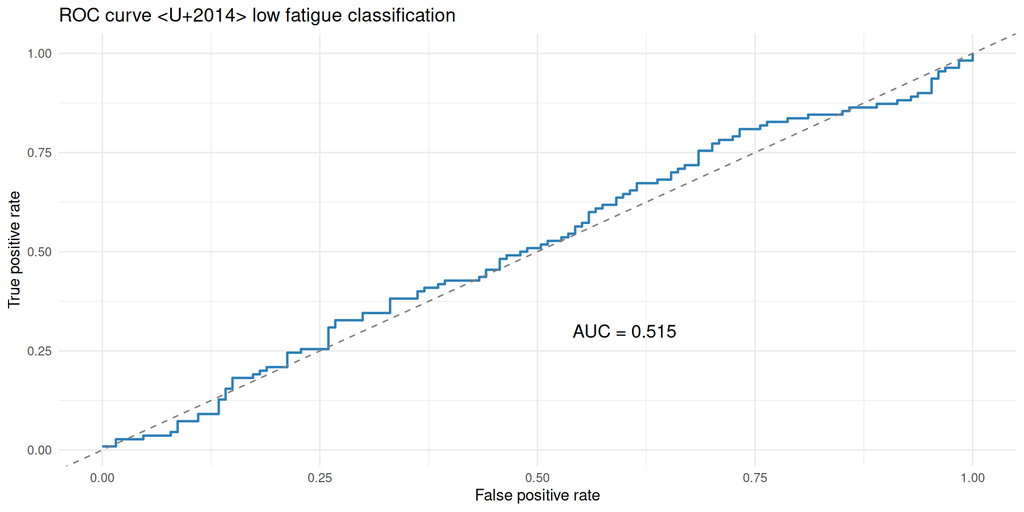

```r
# ROC curve
roc <- tibble(truth = test$LOW_FATIGUE, prob = test$prob) %>%
  arrange(desc(prob)) %>%
  mutate(tpr = cumsum(truth == 1) / sum(truth == 1),
         fpr = cumsum(truth == 0) / sum(truth == 0))

auc_val <- abs(sum(diff(roc$fpr) * (head(roc$tpr, -1) + tail(roc$tpr, -1)) / 2))

ggplot(roc, aes(fpr, tpr)) +
  geom_line(colour = "#2c7fb8", linewidth = 0.8) +
  geom_abline(slope = 1, intercept = 0, linetype = "dashed", colour = "grey50") +
  annotate("text", x = 0.6, y = 0.3, label = sprintf("AUC = %.3f", auc_val), size = 4.5) +
  labs(title = "ROC curve — low fatigue classification",
       x = "False positive rate", y = "True positive rate") +
  theme_minimal()
```

## Interpretation

Each coefficient represents the change in log-odds of low fatigue for a one-unit change in that predictor (holding others constant). The odds ratios are easier to interpret: OR > 1 means higher odds of low fatigue vs. the reference category, OR < 1 means lower odds. CIs crossing 1.0 mean not significant.

```r
sig <- or_tbl %>% filter(term != "(Intercept)", p.value < 0.05)

cat("**Results:**\n\n")
```

**Results:**

```r
if (nrow(sig) == 0) {
  cat("- None of the predictors are statistically significant at p < 0.05.\n")
  cat("- Therapy type, demographics, and prescription volume don't predict fatigue level in this cohort.\n")
} else {
  cat(sprintf("- %d predictor(s) significant at p < 0.05:\n", nrow(sig)))
  for (i in seq_len(nrow(sig))) {
    cat(sprintf("  - **%s**: OR = %.2f (95%% CI: %.2f–%.2f, p = %.3f)\n",
                sig$term[i], sig$estimate[i],
                sig$conf.low[i], sig$conf.high[i], sig$p.value[i]))
  }
}
```

- 1 predictor(s) significant at p < 0.05:
  - **RACEblack**: OR = 0.64 (95% CI: 0.44–0.93, p = 0.020)

```r
cat(sprintf("\n- **AUC = %.3f** — ", auc_val))
```

- **AUC = 0.515** —

```r
if (auc_val < 0.55) {
  cat("basically no better than flipping a coin.\n")
} else if (auc_val < 0.7) {
  cat("weak discriminatory power.\n")
} else {
  cat("moderate to good discriminatory power.\n")
}
```

basically no better than flipping a coin.

```r
cat(sprintf("- **Accuracy = %.1f%%** on held-out test set.\n\n", acc * 100))
```

- **Accuracy = 51.1%** on held-out test set.

```r
cat("**Limitations:**\n\n")
```

**Limitations:**

```r
cat("- This is cross-sectional, not longitudinal. I'm modelling whether fatigue is ",
    "below the median, not whether it improved after treatment. The assignment asks ",
    "for a pre/post comparison, but the data only has one observation per patient.\n")
```

- This is cross-sectional, not longitudinal. I’m modelling whether fatigue is below the median, not whether it improved after treatment. The assignment asks for a pre/post comparison, but the data only has one observation per patient.

```r
cat("- Patients weren't randomly assigned to therapies, so any associations could be confounded.\n")
```

- Patients weren’t randomly assigned to therapies, so any associations could be confounded.

```r
cat("- This is simulated Synthea data, so the lack of signal probably reflects the ",
    "data generation process more than anything clinical.\n")
```

- This is simulated Synthea data, so the lack of signal probably reflects the data generation process more than anything clinical.